# Timepoint comparison on neuron differentiation ASD dataset

## Differential Expression Gene Analysis

Differentially expressed genes were ranked using likelihood ratio test results, and significant genes were selected based on an FDR threshold of 0.05. Gene identifiers were converted from Ensembl to Entrez IDs to enable downstream functional enrichment analysis.

```r
top <- topTags(res, n = Inf)$table

deg <- top[top$FDR <= 0.05,]
dim(deg)
```

```
## [1] 7694    5
```

```r
universo <- substr(row.names(top), 1, 15)
sign <- substr(row.names(deg), 1, 15)

universo.entrez <- mapIds(org.Hs.eg.db,
                          keys = universo,
                          column = "ENTREZID",
                          keytype = "ENSEMBL")
sign.entrez <- mapIds(org.Hs.eg.db,
                      keys = sign,
                      column = "ENTREZID",
                      keytype = "ENSEMBL")
universo.entrez <- as.character(universo.entrez)
sign.entrez <- as.character(sign.entrez)
```

### KEGG Enrichment Analysis

```r
kk <- enrichKEGG(
  gene = sign.entrez,
  universe = universo.entrez,
  organism = "hsa"
)
```

```
## Reading KEGG annotation online: "https://rest.kegg.jp/link/hsa/pathway"...
```

```
## Reading KEGG annotation online: "https://rest.kegg.jp/list/pathway/hsa"...
```

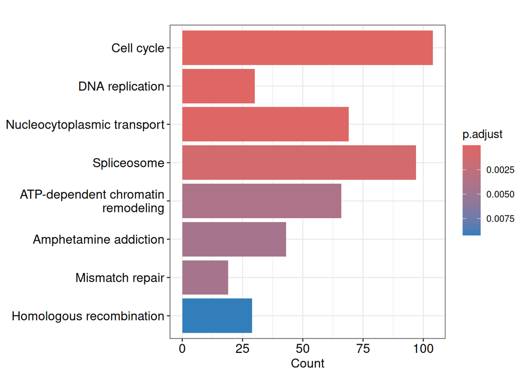

```r
barplot(kk)
```

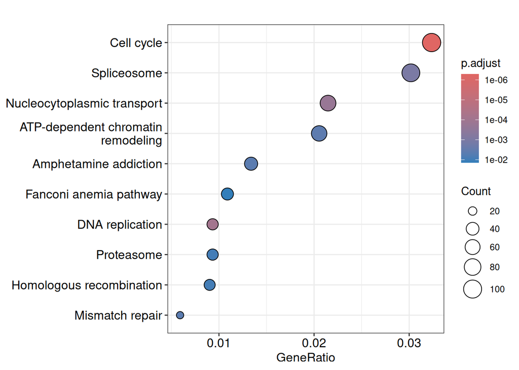

```r
dotplot(kk)
```

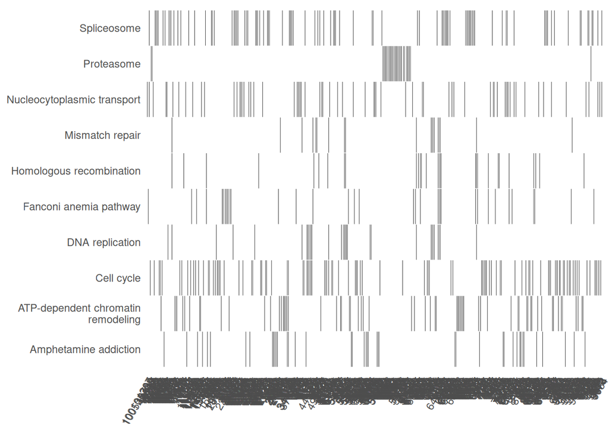

```r
heatplot(kk, showCategory = 10)
```

```r
edo <- pairwise_termsim(kk)
obj <- upsetplot(edo, 8)
obj
```

[output not shown]

### Pathway Similarity Analysis

Gene Ontology (GO) enrichment was performed for Biological Process terms to identify functional categories associated with the differentially expressed genes. Results were summarized using barplots and upset plots to highlight key biological themes.

```r
edo <- pairwise_termsim(kk)
upsetplot(edo, 8)
```

[output not shown]

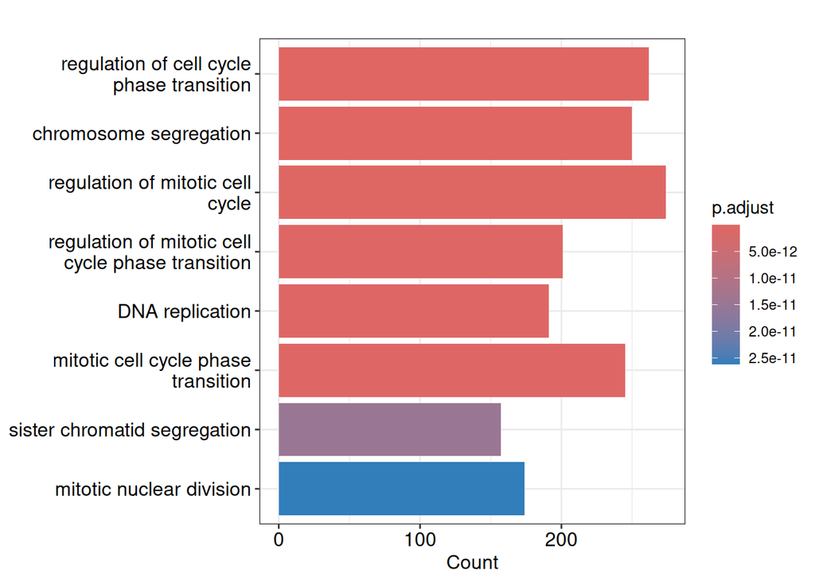

```r
ego <- enrichGO(gene = sign.entrez,
                universe = universo.entrez,
                OrgDb = 'org.Hs.eg.db',
                keyType = "ENTREZID",
                ont = "BP",
                pvalueCutoff = 0.05,
                pAdjustMethod = "BH",
                readable = TRUE)

barplot(ego)
```

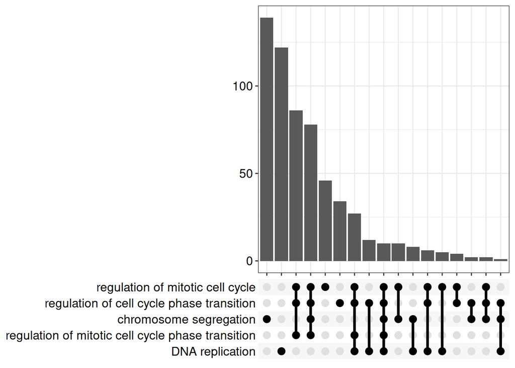

```r
upsetplot(ego, 5)
```

## GSEA Analysis

Gene Set Enrichment Analysis (GSEA) was performed using a ranked list of genes based on log fold change. This approach considers all genes rather than only significant ones, allowing detection of subtle but coordinated pathway-level changes.

```r
tt <- top$logFC
names(tt) <- universo.entrez

table(duplicated(names(tt)))
```

```
##
## FALSE  TRUE
## 21109    49
```

```r
tt <- tt[!duplicated(names(tt))]

sort_tt <- sort(tt, decreasing = TRUE)

kk2 <- gseKEGG(
  geneList = sort_tt,
  organism = "hsa",
  pvalueCutoff = 0.05

)

kkGO <- gseGO(
  geneList = sort_tt,
  ont = "BP",
  OrgDb = 'org.Hs.eg.db',
  keyType = "ENTREZID",
  pAdjustMethod = "BH"
)
```

#### Using LR as the statistical variable (true statistical variable)

An additional GSEA was performed using the likelihood ratio statistic as the ranking metric, which better reflects statistical strength of differential expression. This provides a more robust view of pathway enrichment driven by true model-based significance.

```r
test <- top$LR*sign(top$logFC)
names(test) <- universo.entrez

table(duplicated(names(test)))
```

```
##
## FALSE  TRUE
## 21109    49
```

```r
test <- test[!duplicated(names(test))]

sort_test <- sort(test, decreasing = TRUE)

kk2t <- gseKEGG(
  geneList = sort_test,
  organism = "hsa",
  pvalueCutoff = 0.05

)


kkGOt <- gseGO(
  geneList = sort_test,
  ont = "BP",
  OrgDb = 'org.Hs.eg.db',
  keyType = "ENTREZID",
  pAdjustMethod = "BH"
)
```

## Testing Biocondunctor Packages

### DEG Analysis version 2

#### Package 1: DESeq2

DESeq2 is a widely used framework for RNA-seq differential expression analysis based on negative binomial models. It handles normalization, dispersion estimation, and statistical testing in a unified pipeline.

Compared to what we used (edgeR + manual design + GLM), DESeq2 provides a more “all-in-one” workflow with strong built-in normalization (size factors) and robust dispersion shrinkage, offering faster computation and a more straightforward pipeline. In practice, both methods often give similar biological results, as is our case, which shows the accuracy of our pipeline.

```r
colData(data_filtered)$timepoint <- factor(colData(data_filtered)$sra.sample_attributes)
dds <- DESeqDataSet(data_filtered, design = ~ timepoint)

all(assay(dds, "counts") == assay(data_filtered, "raw_counts"))
```

```
## [1] TRUE
```

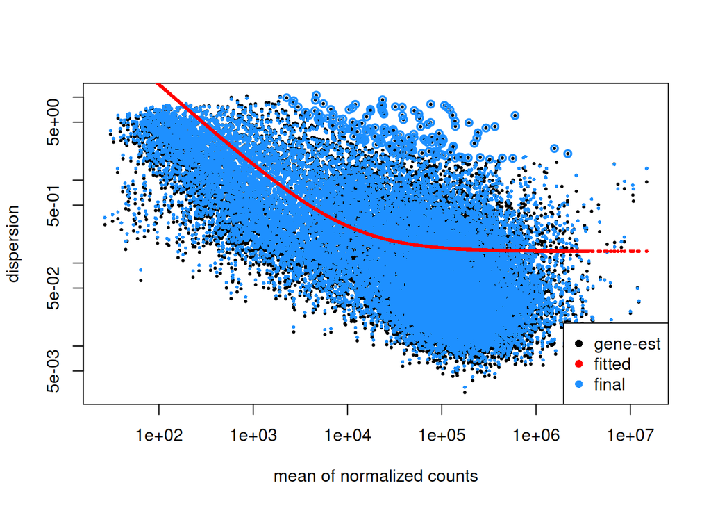

```r
dds <- DESeq(dds)

plotDispEsts(dds)
```

```r
res <- results(dds,
               contrast = c("timepoint", "11", "31"),
               alpha = 0.05)

summary(res)
```

```
##
## out of 21158 with nonzero total read count
## adjusted p-value < 0.05
## LFC > 0 (up)       : 3658, 17%
## LFC < 0 (down)     : 4700, 22%
## outliers [1]       : 0, 0%
## low counts [2]     : 411, 1.9%
## (mean count < 121)
## [1] see 'cooksCutoff' argument of ?results
## [2] see 'independentFiltering' argument of ?results
```

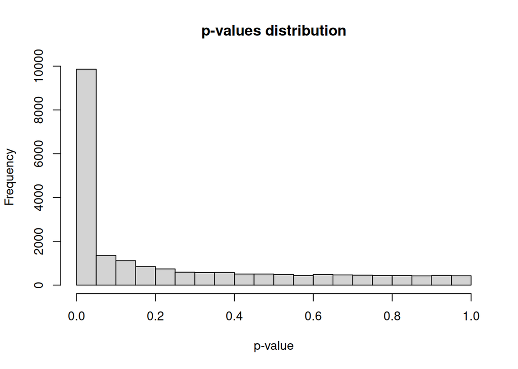

```r
hist(res[order(res$padj), ]$pvalue, main="p-values distribution", xlab = "p-value")
```

#### Package 2: apeglm

apeglm is used for log fold change shrinkage after differential expression testing (typically with DESeq2). It improves logFC estimates by shrinking extreme values toward zero, especially for low-count or noisy genes.

Compared to our current approach (raw logFC from GLM in edgeR), apeglm produces more conservative and biologically realistic effect sizes. This makes rankings and visualizations (like volcano plots) more stable and less dominated by exaggerated fold changes from low-expression genes.

```r
res_shrunk <- lfcShrink(dds,
                        coef = "timepoint_31_vs_11",
                        type = "apeglm")
```

```
## using 'apeglm' for LFC shrinkage. If used in published research, please cite:
##     Zhu, A., Ibrahim, J.G., Love, M.I. (2018) Heavy-tailed prior distributions for
##     sequence count data: removing the noise and preserving large differences.
##     Bioinformatics. https://doi.org/10.1093/bioinformatics/bty895
```

**MA Plot**

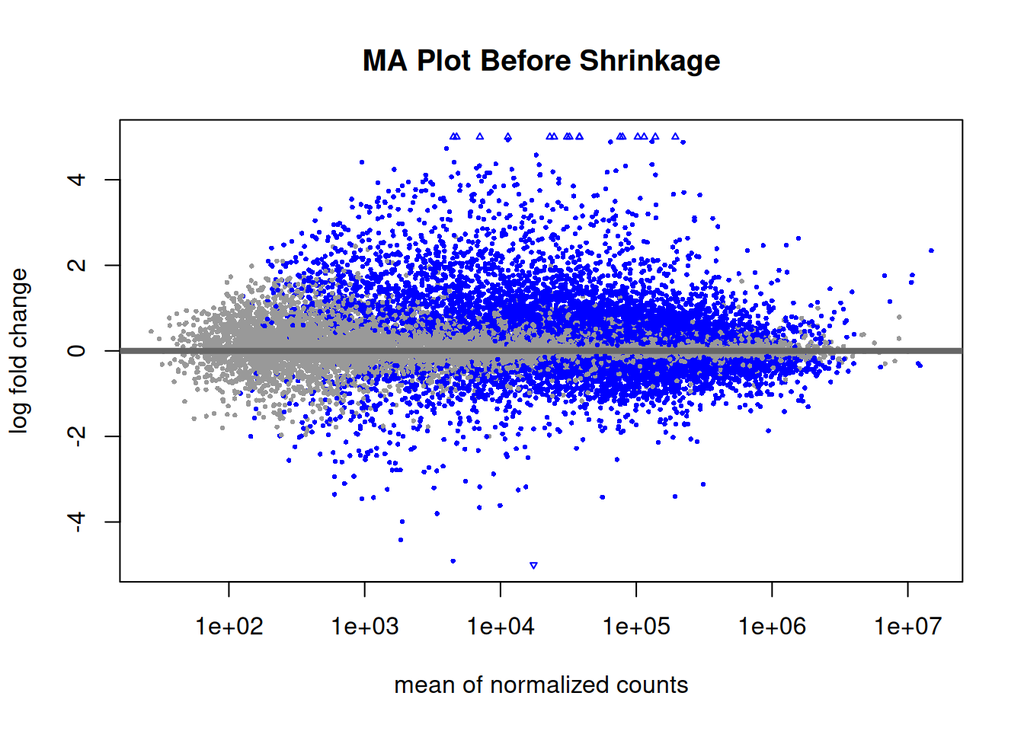

```r
plotMA(dds, ylim = c(-5, 5), main = "MA Plot Before Shrinkage")
```

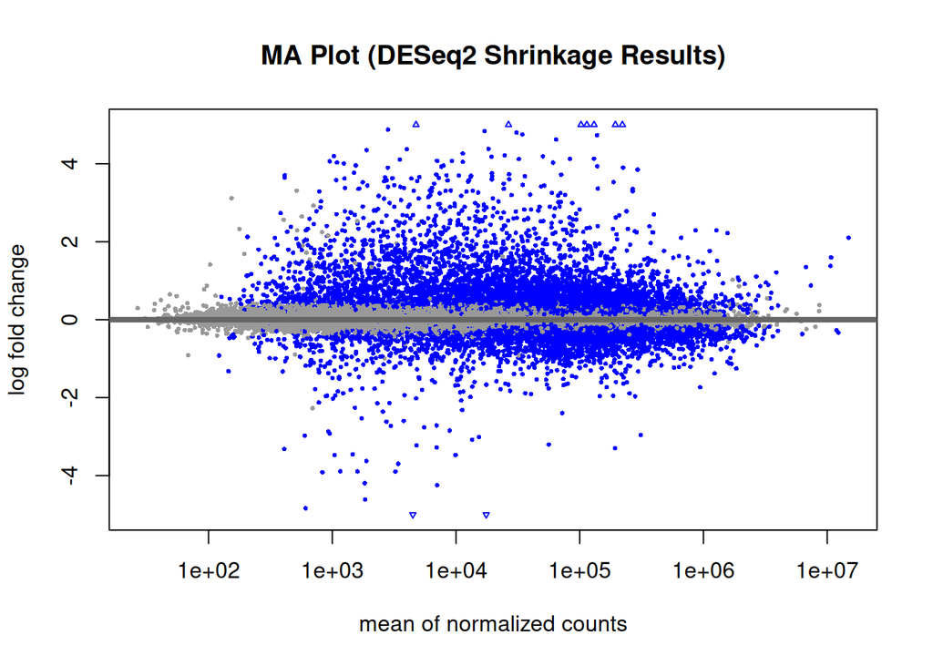

```r
plotMA(res_shrunk, ylim = c(-5, 5), main = "MA Plot (DESeq2 Shrinkage Results)")
```

#### Package 3: Enhanced Volcano

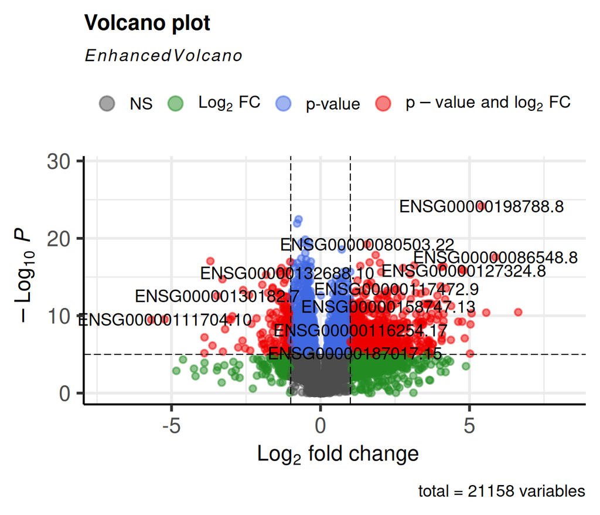

```r
EnhancedVolcano(res_shrunk,
                lab = rownames(res_shrunk),
                x = "log2FoldChange",
                y = "pvalue")
```

### GSEA Analysis version 2

#### Gene Set Analysis using the new DEG

```r
rownames(res_shrunk) <- gsub("\\..*", "", rownames(res_shrunk))
gene_mapping <- bitr(rownames(res_shrunk),
                     fromType = "ENSEMBL",
                     toType   = c("ENTREZID", "SYMBOL"),
                     OrgDb    = org.Hs.eg.db)
res_df <- as.data.frame(res_shrunk) |>
  tibble::rownames_to_column("ENSEMBL") |>
  dplyr::left_join(gene_mapping, by = "ENSEMBL") |>
  tidyr::drop_na(ENTREZID, log2FoldChange, padj)

sig_genes <- res_df |>
  dplyr::filter(padj < 0.05, abs(log2FoldChange) > 1) |>
  dplyr::pull(ENTREZID)

universe <- res_df$ENTREZID

ora_go <- enrichGO(gene         = sig_genes,
                   universe     = universe,
                   OrgDb        = org.Hs.eg.db,
                   ont          = "BP",
                   pAdjustMethod = "BH",
                   pvalueCutoff  = 0.05,
                   qvalueCutoff  = 0.2,
                   readable     = TRUE)

ora_kegg <- enrichKEGG(gene         = sig_genes,
                       universe     = universe,
                       organism     = "hsa",
                       pAdjustMethod = "BH",
                       pvalueCutoff  = 0.05)

ranked <- res_df |>
  dplyr::arrange(dplyr::desc(log2FoldChange)) |>
  dplyr::mutate(rank_stat = sign(log2FoldChange) * -log10(pvalue)) |>
  dplyr::distinct(ENTREZID, .keep_all = TRUE)

gene_list <- setNames(ranked$rank_stat, ranked$ENTREZID)

gsea_go <- gseGO(geneList     = gene_list,
                 OrgDb        = org.Hs.eg.db,
                 ont          = "BP",
                 minGSSize    = 15,
                 maxGSSize    = 500,
                 pAdjustMethod = "BH",
                 pvalueCutoff  = 0.05,
                 verbose      = FALSE)

gsea_kegg <- gseKEGG(geneList     = gene_list,
                     organism     = "hsa",
                     minGSSize    = 15,
                     pAdjustMethod = "BH",
                     pvalueCutoff  = 0.05,
                     verbose      = FALSE)
```

Plots for representing the enrich results

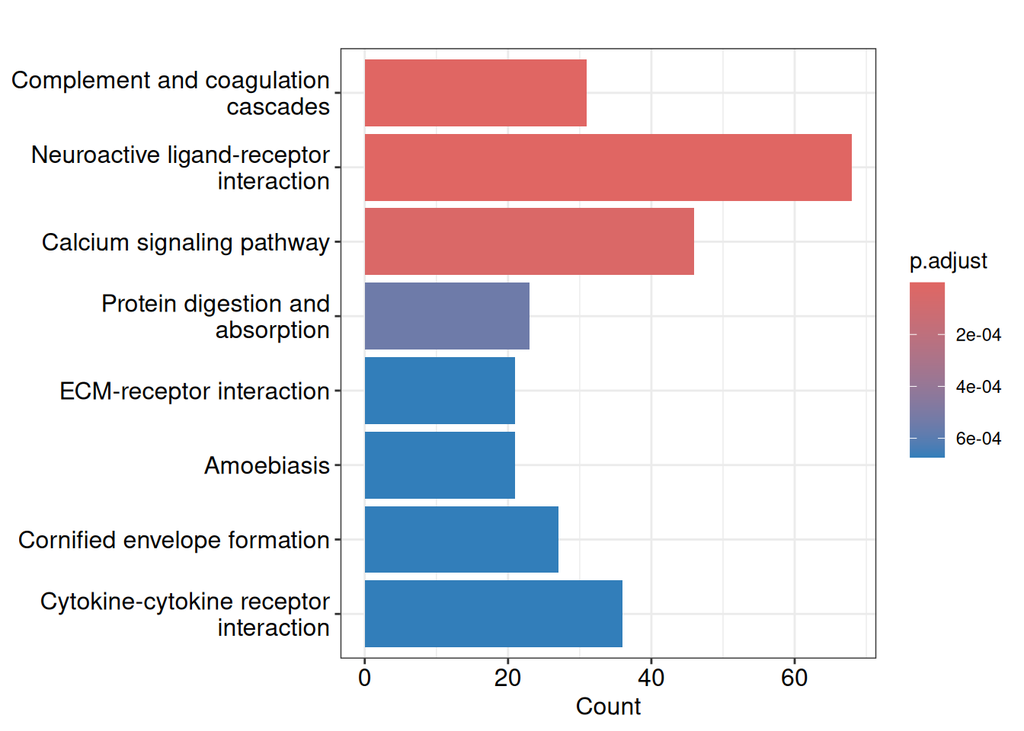

```r
barplot(ora_kegg)
```

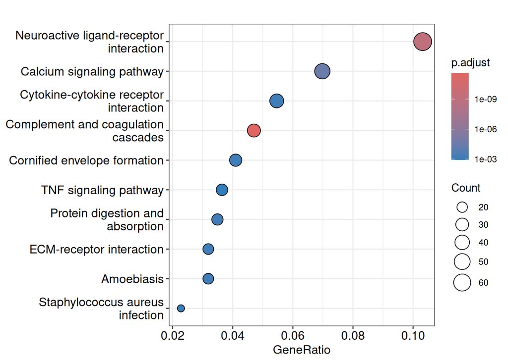

```r
dotplot(ora_kegg)
```

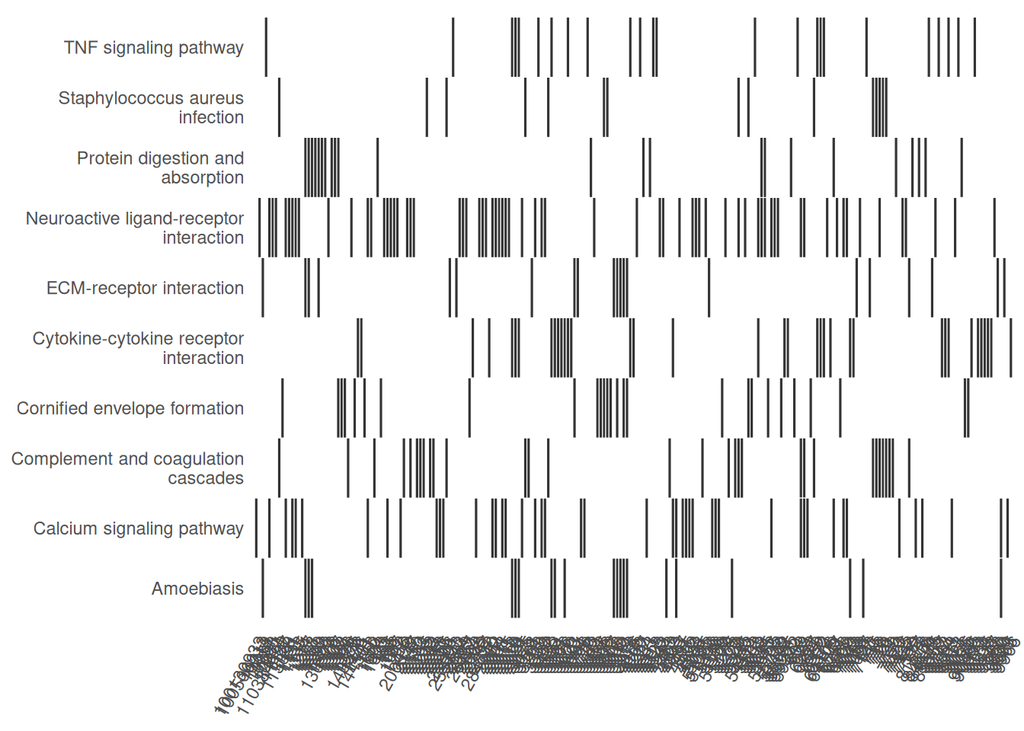

```r
heatplot(ora_kegg, showCategory = 10)
```

```r
edo_orak <- pairwise_termsim(ora_kegg)
obj_orak <- upsetplot(edo, 8)
obj_orak
```

[output not shown]

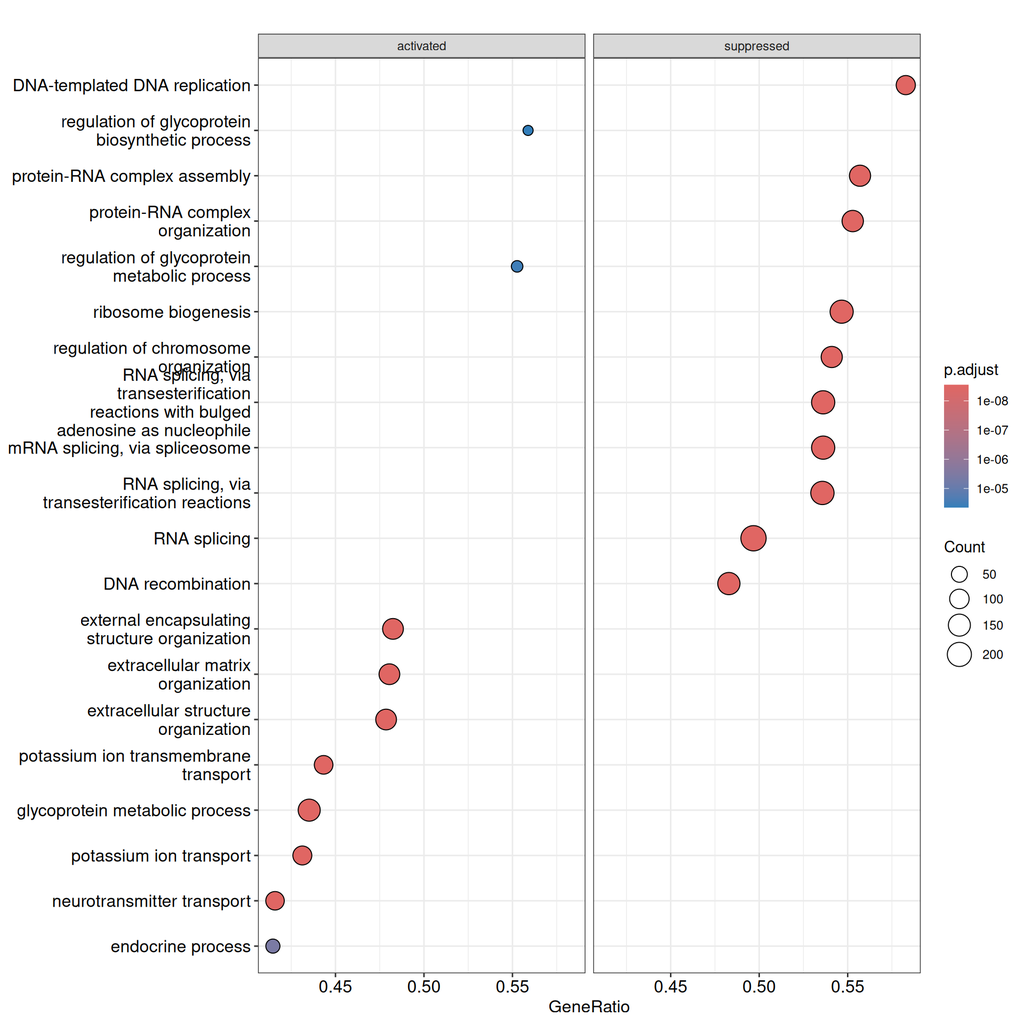

```r
dotplot(gsea_go,   showCategory = 10, split = ".sign") + facet_grid(. ~ .sign)
```

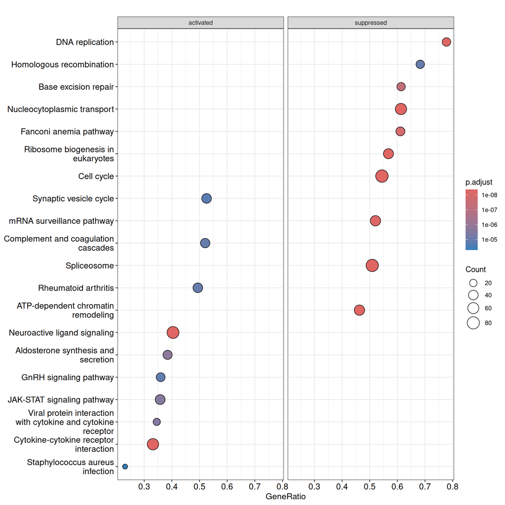

```r
dotplot(gsea_kegg, showCategory = 10, split = ".sign") + facet_grid(. ~ .sign)
```

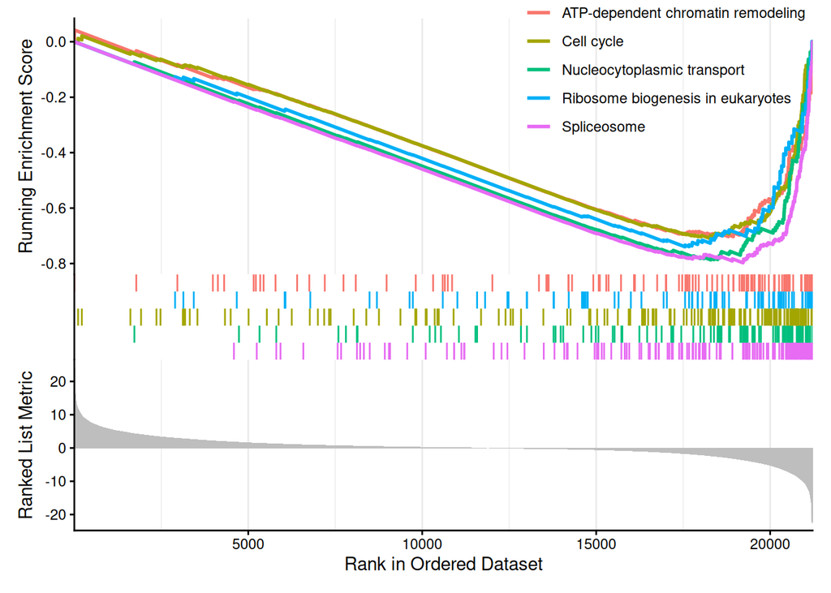

```r
gseaplot2(gsea_kegg, geneSetID = 1:5)
```

**Comparison of GSEA Results**

```r
kegg_original <- inner_join(
  kk2@result[,], kk2t@result[,], by = c("ID", "Description")
)

kegg_new <- inner_join(
  gsea_kegg@result[,], ora_kegg@result[,], by=c("ID", "Description")
)

kegg_total <- inner_join(
  kegg_original, kegg_new, by=c("ID", "Description")
)


GO_original <- inner_join(
  ego@result[,], kkGO@result[,], by=c("ID", "Description")
)

GO_original <- inner_join(
  GO_original[,], kkGOt@result[,], by=c("ID", "Description")
)

GO_new <- inner_join(
  ora_go@result[,], gsea_go@result[,], by=c("ID", "Description")
)

GO_total <- inner_join(
  GO_original[,], GO_new[,], by=c("ID", "Description")
)
```